# Installing Rust for vLLM on Graviton: a G5g walk-through 🦀

[figure not shown]

This tutorial walks through installing and setting up the **Rust toolchain for vLLM** on an AWS EC2 **G5g** instance — Graviton2 (aarch64) with an NVIDIA T4G GPU — and getting vLLM's Rust frontend (`vllm-rs`) built, running, and *verified*.

If you build vLLM from source, some of this applies to you on any architecture: since v0.27.2rc0 the build has a hard Rust dependency. The aarch64 + Turing box is just where every sharp edge shows up at once.

Everything below was run on the box. 🦀

#### Wait, vLLM has Rust in it?

You betcha. Since [PR #40848](https://github.com/vllm-project/vllm/pull/40848) (merged 2026-05-21), vLLM vendors a **14-crate Rust workspace**:

```
bench  chat  cmd  engine-core-client  llm  managed-engine  metrics
mock-engine  parser  parser/python  server  text  tokenizer  tracing
```

Edition 2024, resolver 3. Straight from the vendored `rust/Cargo.toml`:

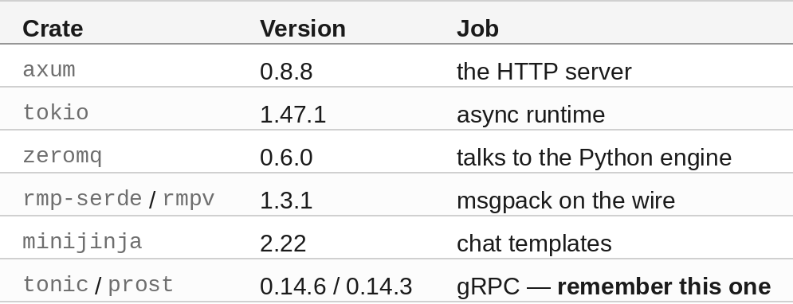

It's a drop-in replacement for the Python FastAPI server. Two artifacts get built:

- 🦀 **`vllm-rs`** — the axum frontend binary
- 🐍 **`vllm._rust_tool_parser`** — a PyO3 extension module

#### Rust is a build requirement now

That's the headline, and it's reason enough on its own: **you cannot build vLLM from source at v0.27.2rc0 without Rust in the picture.** `setup.py` imports it at module scope, line 21, unguarded:

```python
from setuptools_rust.build import build_rust
```

No `try`, no feature flag, no opt-out. Metadata generation doesn't happen without it.

And this isn't a quirk of one release. vLLM's Rust surface is **14 crates** covering the HTTP frontend, the tool parser, the tokenizer and the benchmark client, and it has been growing since it landed. If you build inference infrastructure from source, a Rust toolchain is becoming table stakes — so it's worth knowing how to drive it properly rather than working around it.

Three things do get conflated, though, and they have different scopes:

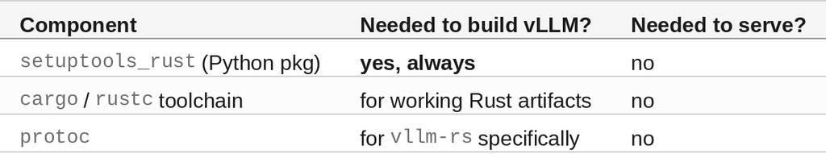

#### Then why doesn't `pip install vllm` need this?

Because normally pip installs it for you. `pyproject.toml` declares it:

```
[build-system]
requires = [
    "cmake>=3.26.1", "ninja", "packaging>=24.2",
    "setuptools>=77.0.3,<81.0.0", "setuptools-scm>=8.0",
    "setuptools-rust>=1.9.0",          # <- pip grabs this automatically
    "torch == 2.13.0",                 # <- ...and this. Which is the problem.
    "wheel", "jinja2",
]
```

Under normal **build isolation**, pip creates a clean env, installs that list, and builds. You never see `setuptools_rust` because you never had to think about it.

But look at the `torch` pin. Building in isolation means pip installs **torch 2.13.0 from PyPI** — and the PyPI aarch64 wheels are built for sm_80 and up. **No `sm_75`.** Which destroys the entire reason for building from source on a T4G.

So on this box you must build against the DLAMI's own torch, and that means:

```bash
python use_existing_torch.py
pip install -e . --no-build-isolation
```

**`--no-build-isolation` turns off the automatic install of everything in that `requires` list.** From that moment on, every build dependency is yours to supply by hand — including `setuptools_rust`, which is why it turns up as a bare `ModuleNotFoundError` minutes into a build that has nothing visibly to do with Rust.

So the toolchain was always required; isolation was just hiding it. Building this way means you own the dependency list, which is the rest of this walk-through. ⚡

#### What the DLAMI gives you, and what it doesn't

The AWS Deep Learning ARM64 AMI ships a **runtime**, not a build environment. On a fresh box:

[figure not shown]

Four of those six are on you. Let's install them.

#### Step 1 — Rust itself

Standard rustup, nothing aarch64-specific about it:

```bash
curl --proto '=https' --tlsv1.2 -sSf https://sh.rustup.rs | sh -s -- -y
. "$HOME/.cargo/env"
```

```
stable-aarch64-unknown-linux-gnu installed - rustc 1.97.1 (8bab26f4f 2026-07-14)

Rust is installed now. Great!
```

Note the triple: `stable-aarch64-unknown-linux-gnu`. Rust's aarch64 support is a **complete non-event**, which is a lovely change of pace on this hardware. ⚡

#### Step 2 — setuptools-rust

```bash
python3 -m pip install setuptools_rust
```

Per the section above: `--no-build-isolation` means pip won't do this for you. Do it **early** — the failure lands during metadata generation, minutes into a build, as a bare `ModuleNotFoundError: No module named 'setuptools_rust'` nowhere near anything that looks like Rust.

⚠️ Install it into the **same interpreter you'll build with**. On the DLAMI that's `/opt/pytorch/bin/python3`, not the system `python3` — they're different, and the one that matters is whichever owns the torch you're building against.

#### Step 3 — protoc 🔎

This is the one nobody documents:

```bash
apt-get install -y protobuf-compiler
protoc --version
```

```
libprotoc 3.21.12
```

**Why:** `vllm-rs` depends on the `vllm-server` crate, `vllm-server` builds gRPC stubs with `tonic`/`prost`, and `prost-build` shells out to `protoc`. Skip it and the frontend binary does not get built — see the summary at the end for how loudly that *doesn't* fail.

The tool parser has no protobuf dependency, which is why it builds either way.

#### Step 4 — the CUDA toolkit, while you're here

Not Rust, but the same class of problem, and you need it for vLLM's kernels:

```bash
# NVIDIA's **sbsa** repo — not the x86 one, easy reflex to get wrong on Arm
apt-get install -y cuda-toolkit-13-2
```

#### Step 5 — build the Rust artifacts

```bash
cd /opt/vllm-src
python tools/build_rust.py --release
```

⚠️ **Do not omit `--release`.** setuptools-rust builds inplace targets in debug by default, and `pip install -e .` is an inplace build. The difference is not subtle:

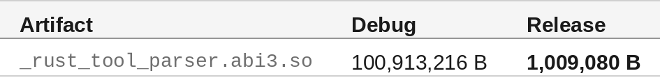

**100x.** The debug artifact is four times the size of *every CUDA kernel in vLLM combined*.

Timing on a `g5g.xlarge` (4 vCPU), cold:

```
real    9m1.746s
user    25m9.199s
sys     1m35.023s
```

**501 crates. Zero warnings. Exit 0.** 🟢

Rust's aarch64 support does not put up a fight here — which is a pleasant contrast with the CUDA side of this box, where SM 7.5 on Graviton needs a custom arch list and a patched kernel.

#### Step 6 — check what you got

```bash
ls -la vllm/vllm-rs vllm/_rust_tool_parser.abi3.so
```

```
-rwxr-xr-x 1 root root 50039024 vllm/vllm-rs
-rwxr-xr-x 1 root root  1009080 vllm/_rust_tool_parser.abi3.so
```

```bash
file vllm/vllm-rs
```

```
ELF 64-bit LSB pie executable, ARM aarch64, version 1 (SYSV),
dynamically linked, interpreter /lib/ld-linux-aarch64.so.1, not stripped
```

```bash
vllm/vllm-rs --help
```

```
Rust frontend and managed-engine CLI for vLLM.

Commands:
  frontend  Run the Rust OpenAI frontend as a Python-supervised worker
  serve     Launch a managed Python headless engine, then run the Rust OpenAI frontend
  bench     Run vLLM benchmarks
  render    Run engine-free request rendering and preprocessing
```

If `vllm/vllm-rs` isn't there, go back to **Step 3**.

#### Step 7 — run it, and mind the entrypoint ⚠️

```bash
VLLM_USE_RUST_FRONTEND=1 vllm serve google/gemma-4-E2B-it \
  --dtype float16 \
  --kv-cache-dtype auto \
  --max-model-len 16384 \
  --gpu-memory-utilization 0.90 \
  --max-num-seqs 8 \
  --tensor-parallel-size 1 \
  --host 0.0.0.0 --port 8000
```

**It must be `vllm serve`.** If you launch the module directly —

```bash
# ❌ VLLM_USE_RUST_FRONTEND is IGNORED here
python -m vllm.entrypoints.openai.api_server --model … --host 0.0.0.0 --port 8000
```

— the variable does nothing. No warning, no `Unknown vLLM environment variable` line. The server comes up healthy and serves happily on the Python frontend, and a benchmark run against it looks entirely normal.

The flag is read in exactly two places:

```
vllm/entrypoints/cli/serve.py:62        envs.VLLM_RUST_FRONTEND_PATH if envs.VLLM_USE_RUST_FRONTEND else None
vllm/entrypoints/openai/dp_supervisor.py:261   if envs.VLLM_USE_RUST_FRONTEND and envs.VLLM_RUST_FRONTEND_PATH:
```

`api_server.py` never mentions it.

#### How do I know it's actually Rust? 🔎

Three checks. Do all three the first time.

**1. The `server:` header:**

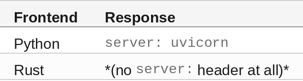

```bash
curl -si localhost:8000/health | grep -i '^server:'
```

**2. The process:**

```bash
pgrep -af vllm-rs
```

```
26588 /opt/vllm-src/vllm/vllm-rs frontend --listen-fd 17
  --input-address  ipc:///tmp/f60f3962-d45b-4bcd-9026-c0dc32736028
  --output-address ipc:///tmp/5f75411d-2787-43bb-b4fc-14bf504a1cce
  --engine-start-index 0 --engine-count 1 --data-parallel-size 1
```

**3. The log prefix** — `(RustFrontend pid=…)` instead of `(APIServer pid=…)`:

```
INFO [utils.py:392] Launching Rust frontend: /opt/vllm-src/vllm/vllm-rs frontend --listen-fd 17 …
```

#### So where does Rust actually sit?

In **two** places, and they're quite different. One is a separate process; the other is a shared object loaded *inside* the Python process. Here's the whole VM:

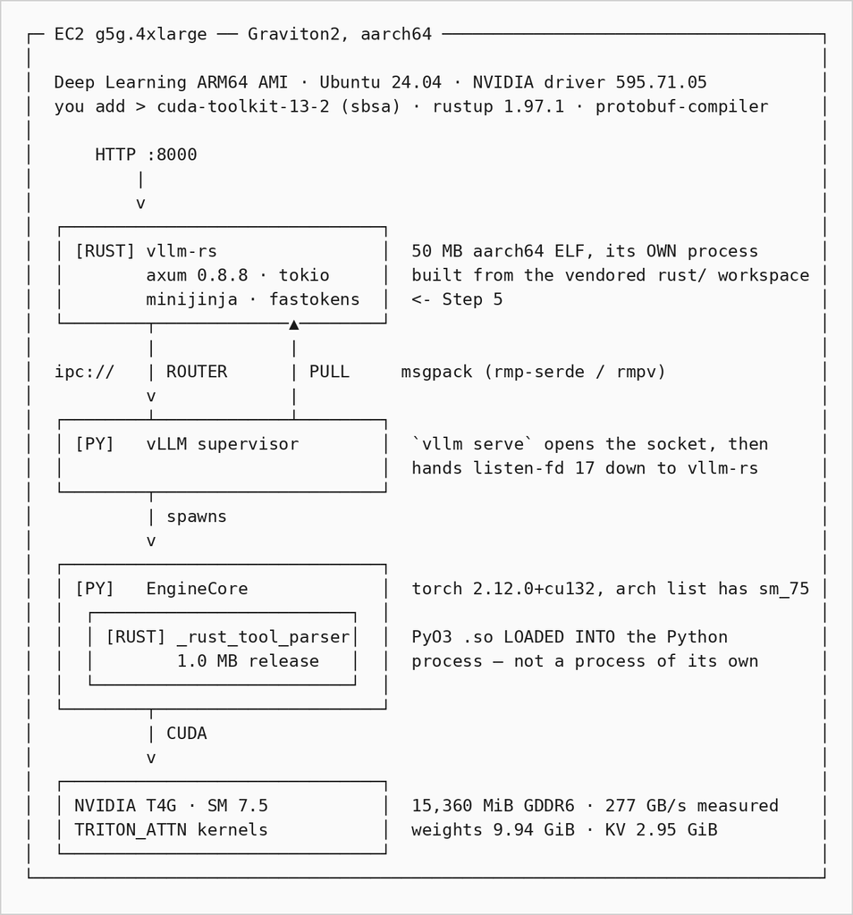

Two things worth pulling out of that picture:

- **`vllm-rs` is not a sidecar you point at a port.** The Python side opens the listening socket and passes the *file descriptor* down. It's a worker the supervisor forks and feeds.
- **`_rust_tool_parser` is Rust living inside Python.** It's the one that always builds (no `protoc` needed), which is why a broken install still leaves Rust on the box — just not the Rust you wanted.

And note where the GPU sits relative to all of this: at the bottom, behind everything. That's the reason the benchmark below comes out the way it does.

#### Bonus: there's a Rust benchmark client too

```bash
VLLM_USE_RUST_BENCH=1 vllm bench serve …
```

Same binary, `bench` subcommand. Requires `VLLM_RUST_FRONTEND_PATH` to resolve, so it needs the same Step 3 → Step 5 you just did.

#### Two warnings you should not scroll past 🔴

The server came up healthy. These went by in the startup log anyway.

**Gemma 4 defeats the fast tokenizer:**

```
INFO    [hf.rs:200] loading tokenizer with fastokens
WARNING [hf.rs:221] failed to load tokenizer with fastokens; falling back to
        HuggingFace tokenizers
        error=tokenizer error: normalizer error: unsupported normalizer type: Replace
```

`fastokens` 0.2.1 doesn't implement the `Replace` normalizer that Gemma 4's `tokenizer.json` uses, so it falls back to the same HuggingFace `tokenizers` the Python path uses. Note the fallback is graceful and correct — you just don't get the fast path on *this* model yet. It's a coverage gap in a young crate, and one normalizer away from closing.

**Multimodal isn't wired up for this model:**

```
WARNING [multimodal.rs:446] multimodal model spec is not registered; disabling
        image/video support   model_id="google/gemma-4-E2B-it" model_type="gemma4"
```

Gemma 4 E2B is a **vision** model, and `gemma4` isn't in the Rust multimodal spec table yet. Text requests behave identically and the endpoint is healthy, so nothing in a normal check reveals it. Also a registration gap rather than a design problem — but check it for your model before you switch, because a healthy endpoint won't tell you.

#### Is it faster?

On a T4G, no. Output token throughput, same engine config, client on the box against localhost:

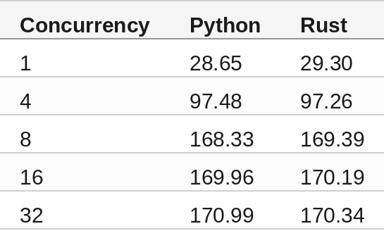

Median TTFT tracks just as tightly — 14305 ms against 14311 ms at concurrency 32.

That's the expected result, and worth saying plainly: decode on this card is **bandwidth-bound** at a measured 277 GB/s, and the engine saturates at `--max-num-seqs 8`. A frontend rewrite targets CPU-side per-request overhead. Here that overhead hides behind the GPU, so swapping it can't move a bottleneck-limited number. **If you want the Rust frontend to buy you tokens per second on a small GPU, it won't.**

One signal does appear, in median inter-token latency at high concurrency:

[figure not shown]

Mean TPOT barely moves, so this is the middle of the distribution tightening rather than everything speeding up — the shape you'd expect from a frontend scheduling streaming work more evenly once many streams are in flight. Worth knowing if you serve at concurrency; not worth switching for on its own. 📊

#### If a plain `pip install -e .` already ran

A from-source vLLM install done **without** the steps above succeeds, exits 0, and leaves you with a 96 MB debug tool parser and no frontend binary. Four defaults stack up to make that silent:

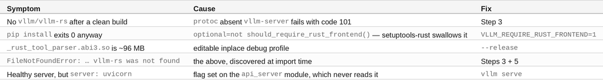

`VLLM_REQUIRE_RUST_FRONTEND=1` turns the second row into a hard build failure, which is what you want on any machine you plan to serve from.

#### Cheat sheet

```bash
# toolchain — you supply these by hand because the sm_75 requirement
# forces --no-build-isolation, which disables pip's automatic build deps
curl --proto '=https' --tlsv1.2 -sSf https://sh.rustup.rs | sh -s -- -y
. "$HOME/.cargo/env"
/opt/pytorch/bin/python3 -m pip install setuptools_rust   # the BUILD interpreter
apt-get install -y protobuf-compiler cuda-toolkit-13-2

# build against the DLAMI's torch, not a PyPI one (PyPI aarch64 has no sm_75)
cd /path/to/vllm
python use_existing_torch.py
TORCH_CUDA_ARCH_LIST=7.5 VLLM_REQUIRE_RUST_FRONTEND=1 \
  pip install -e . --no-build-isolation

# Rust artifacts, release profile (editable installs default to debug: 100x bigger)
VLLM_REQUIRE_RUST_FRONTEND=1 python tools/build_rust.py --release

# confirm
ls -la vllm/vllm-rs && vllm/vllm-rs --help

# run — `vllm serve`, NOT the api_server module
VLLM_USE_RUST_FRONTEND=1 vllm serve <model> --host 0.0.0.0 --port 8000

# verify it's really Rust
curl -si localhost:8000/health | grep -i '^server:'   # Rust sends none
pgrep -af vllm-rs
```

*Run on EC2 `g5g.xlarge` and `g5g.4xlarge`, `us-east-1a`, NVIDIA T4G (SM 7.5). vLLM `0.27.2rc1.dev0+g7f7a32cfe`, rustc 1.97.1, setuptools-rust 1.13.0, libprotoc 3.21.12, torch 2.12.0+cu132. Benchmarks are one run per cell for Rust and two for Python; treat the TPOT delta as suggestive.*